# Bootstrap with replicate

DS705

4/2/2018

## Example from presentation

We’ll create an artificial problem to illustrate. Here are two samples from exponential distributions with different means.

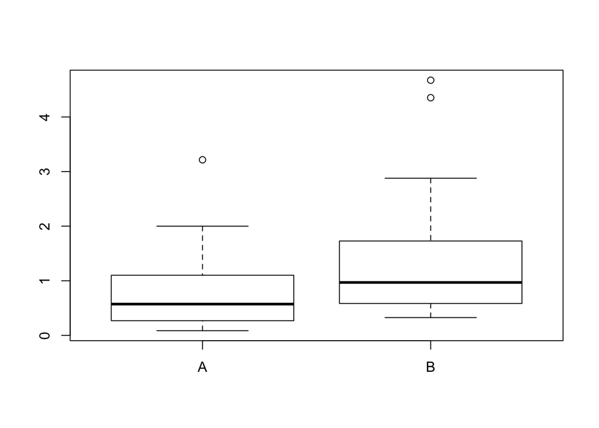

```r
set.seed(321)
x <- c( rexp(20), rexp(20)+.25)
g <- factor( rep(c('A','B'),each=20) )
boxplot(x~g)
```

Clearly the data is a bit skewed with some outliers. We want to test if the two population means are different (they actually are since we shifted the ‘B’ population).
$$H_0: \mu_A = \mu_B, H_a: \mu_A \neq \mu_B$$
The usual $t$-test isn’t appropriate with the small samples from skewed distributions, but if we try to do it anyway we get

```r
out <- t.test(x~g) # you could also do t.test( x[1:20], x[21:40] )
test.stat = out$statistic
p.value = out$p.value
test.stat
```

```
##         t
## -1.861313
```

```r
p.value
```

```
## [1] 0.07220464
```

So using a t-distribution to model the distribution of test statistics we find that about 7% of samples would yield test statistics $t < -1.86$ or $t>1.86$ if the null hypothesis were true. If we were testing with $\alpha = 0.05$ we wouldn’t reject the null hypothesis. However, we should be a bit skeptical here since the populations are not normal the t-distribution might not be an accurate model for the distribution of test-statistics.

Since the t-distribution isn’t a great model here, we’ll use bootstrapping to approximate the sampling distribution of test statistics. From there we can approximate the p-value. First we’ll take the two samples and shift them to each have mean 0 so that the null hypothesis is satistified by the shifted samples.

```r
xnull = c( x[1:20]-mean(x[1:20]), x[21:40]-mean(x[21:40]))
# it's not essential to but these together in one vector
```

The shifted samples are now our pseudo-populations. We’re going to resample with replacement from each of these 5000 times and store the values in `rs`

```r
set.seed(123) # not required but makes reproducible results
rs <- rbind(replicate( 5000, sample( xnull[1:20], replace = T) ),
  replicate( 5000, sample( xnull[21:40], replace = T) ) )
# you'll have to replace xnull[1:20] and xnull[21:40] with the shifted samples for your problem
# IMPORTANT:  each column of rs now contains a pair of resamples from pseudo-populations that satisfy the null hypothesis
# the first part of the column is from 'A' and the second part is from 'B'
```

Now we need to apply the two-sample t-test to each column. Somehow we’ll have to tell t.test where to find each sample in the column. Perhaps the simplest way to do this is with a for loop

```r
bootdist1 = numeric(5000)
for (i in 1:5000){
  c = rs[,i] # extract column i from rs
  bootdist1[i] = t.test( c ~ g)$statistic  # this works because the grouping factor variable has 20 A's followed by 20 B's
  # ^ that wouldn't work if the location of the samples in c was different than in the original x
  # you could also do this
  # bootdist1[i] = t.test( c[1:20], c[21:40])$statistic
}
```

The `apply` command can be used instead of for loops in R and is often much faster, but can be more confusing.

```r
bootdist2 <- apply(rs, 2,
                  function(c) t.test(c~g)$statistic )
```

Because of the 2 in the second argument, apply will loop over each of the columns in rs and “apply” the function in the third argument to each column. The way we’ve written the function here is called an anonymous function since it doesn’t have a name and is a way of writing short functions “inline” with other code. `c` is a dummy variable so this function takes whatever gets passed in for `c` and does something to it … we could have just as easily called it `x` or anything else. Because we’re using apply() on the columns `c` ends up being a column of the matrix rs and our function is supposed to apply the two sample t.test to the samples in `c`, but we have to tell it how. Remember `g` is the group or factor variable from before and since `c` represents a column of `rs` it will have the two samples stacked in it in the same way as the orginal vector `x`.

You could alternately write the function like this: `function(c) t.test(c[1:20],c[21:40])$statistic`. Remember `c` is just our dummy variable name for what ends up being a column of `rs`. We have to apply `t.test` to that column `c`.

These two methods of computing bootdist should be equivalent. Let’s check:

```r
head(bootdist1)
```

```
## [1] -1.6235917  2.2187662  1.8913446 -0.4648380 -0.5797255  1.3330286
```

```r
head(bootdist2)
```

```
## [1] -1.6235917  2.2187662  1.8913446 -0.4648380 -0.5797255  1.3330286
```

Now to finish the problem we’re going to need to approximate the p-value from our empirical sampling distribution stored in `bootdist2`. We’re still trying to answer the same question as when we used the analytical distribution - what is the probability of getting a test statistic as extreme as the one computed from the original data. In this case, what is the probability that $t < -1.86$ or $t > 1.86.$. The original test statistic is still stored in `test.stat` from above so:

```r
# for asymmetric distributions the two-tailed P-value is
# ambiguous.  A common solution is to find smaller of the
# left and right tails and then double it.
P <- 2*min( sum( bootdist2 < test.stat), sum( bootdist2 > test.stat ) )/5000
P
```

```
## [1] 0.0428
```

Now the p-value is smaller than $\alpha = 0.05$ so we reject the null. This is probably a more reliable conclusion since the original $t$-test is not accurate here.